# Data Preprocessing with {tidymodels} and R

Machine Learning

Feature Engineering

Author

Angel Feliz

Published

April 27, 2025

# Introduction

Data preprocessing is the cornerstone of robust machine learning pipelines. Drawing from Max Kuhn’s *Applied Predictive Modeling*, this guide explores essential transformations through the {tidymodels} lens. We’ll bridge theory with practical implementation, examining when, why, and how to apply each technique while weighing their tradeoffs.

# 1 Foundational Transformations

## 1.1 Centering and Scaling

**When to Use**:

- Models sensitive to predictor magnitude (SVM, KNN, neural networks)
- Before dimensionality reduction (PCA) or spatial sign transformations
- When predictors have different measurement scales

**Why It Matters**:

- Centers variables around zero (μ=0)
- Standardizes variance (σ=1)
- Enables meaningful coefficient comparisons
- Critical for distance-based calculations and numerical stability

**Implementation**:

```r
library(tidymodels)

norm_recipe <- recipe(mpg ~ ., data = mtcars) |>
  step_normalize(all_numeric_predictors()) |>
  prep()

bake(norm_recipe, new_data = NULL) |> summary()
```

```
      cyl              disp               hp               drat
 Min.   :-1.225   Min.   :-1.2879   Min.   :-1.3810   Min.   :-1.5646
 1st Qu.:-1.225   1st Qu.:-0.8867   1st Qu.:-0.7320   1st Qu.:-0.9661
 Median :-0.105   Median :-0.2777   Median :-0.3455   Median : 0.1841
 Mean   : 0.000   Mean   : 0.0000   Mean   : 0.0000   Mean   : 0.0000
 3rd Qu.: 1.015   3rd Qu.: 0.7688   3rd Qu.: 0.4859   3rd Qu.: 0.6049
 Max.   : 1.015   Max.   : 1.9468   Max.   : 2.7466   Max.   : 2.4939
       wt               qsec                vs               am
 Min.   :-1.7418   Min.   :-1.87401   Min.   :-0.868   Min.   :-0.8141
 1st Qu.:-0.6500   1st Qu.:-0.53513   1st Qu.:-0.868   1st Qu.:-0.8141
 Median : 0.1101   Median :-0.07765   Median :-0.868   Median :-0.8141
 Mean   : 0.0000   Mean   : 0.00000   Mean   : 0.000   Mean   : 0.0000
 3rd Qu.: 0.4014   3rd Qu.: 0.58830   3rd Qu.: 1.116   3rd Qu.: 1.1899
 Max.   : 2.2553   Max.   : 2.82675   Max.   : 1.116   Max.   : 1.1899
      gear              carb              mpg
 Min.   :-0.9318   Min.   :-1.1222   Min.   :10.40
 1st Qu.:-0.9318   1st Qu.:-0.5030   1st Qu.:15.43
 Median : 0.4236   Median :-0.5030   Median :19.20
 Mean   : 0.0000   Mean   : 0.0000   Mean   :20.09
 3rd Qu.: 0.4236   3rd Qu.: 0.7352   3rd Qu.:22.80
 Max.   : 1.7789   Max.   : 3.2117   Max.   :33.90
```

**Pros**:

- Required for distance-based algorithms
- Improves numerical stability
- Facilitates convergence in gradient-based methods

**Cons**:

- Loses original measurement context
- Not needed for tree-based models
- Sensitive to outlier influence

**Warning**

Always calculate scaling parameters from training data only to avoid data leakage. Resampling should encapsulate preprocessing steps for honest performance estimation.

## 1.2 Resolving Skewness

**When to Use**:

- Smallest to largest ratio > 20 (max/min)
- Right/left-tailed distributions (|skewness| > 1)
- Before linear model assumptions
- When preparing for PCA or other variance-sensitive methods

**Skewness Formula**:

$$skewness = \frac{\sum(x_i - \bar{x})^3}{(n-1)v^{3/2}} \quad \text{where } v = \frac{\sum(x_i - \bar{x})^2}{(n-1)}$$

**Box-Cox Implementation**:

```r
data(ames, package = "modeldata")

skew_recipe <- recipe(Sale_Price ~ Gr_Liv_Area, data = ames) |>
  step_BoxCox(Gr_Liv_Area, limits = c(-2, 2)) |> # MLE for λ
  prep()

tidy(skew_recipe) # Shows selected λ value
```

[output not shown]

```
# A tibble: 1 × 6
  number operation type   trained skip  id
   <int> <chr>     <chr>  <lgl>   <lgl> <chr>
1      1 step      BoxCox TRUE    FALSE BoxCox_SJHua
```

```r
# Calculate original skewness
ames |>
  summarize(skewness = moments::skewness(Gr_Liv_Area))
```

```
# A tibble: 1 × 1
  skewness
     <dbl>
1     1.27
```

**Transformation Options**:

- λ=2 → Square
- λ=0.5 → Square root
- λ=-1 → Inverse
- λ=0 → Natural log

**Cons**:

- Requires strictly positive values
- Loses interpretability
- Sensitive to outlier influence

# 2 Advanced Techniques

## 2.1 Spatial Sign for Outliers

**When to Use**:

- High-dimensional data
- Models sensitive to outlier magnitude (linear regression)
- When robust scaling isn’t sufficient
- Dealing with radial outliers in multidimensional space

**Critical Considerations**:

- Investigate outliers for data entry errors first
- Consider cluster validity before removal
- Understand missingness mechanism (MCAR/MAR/MNAR)

**Implementation**:

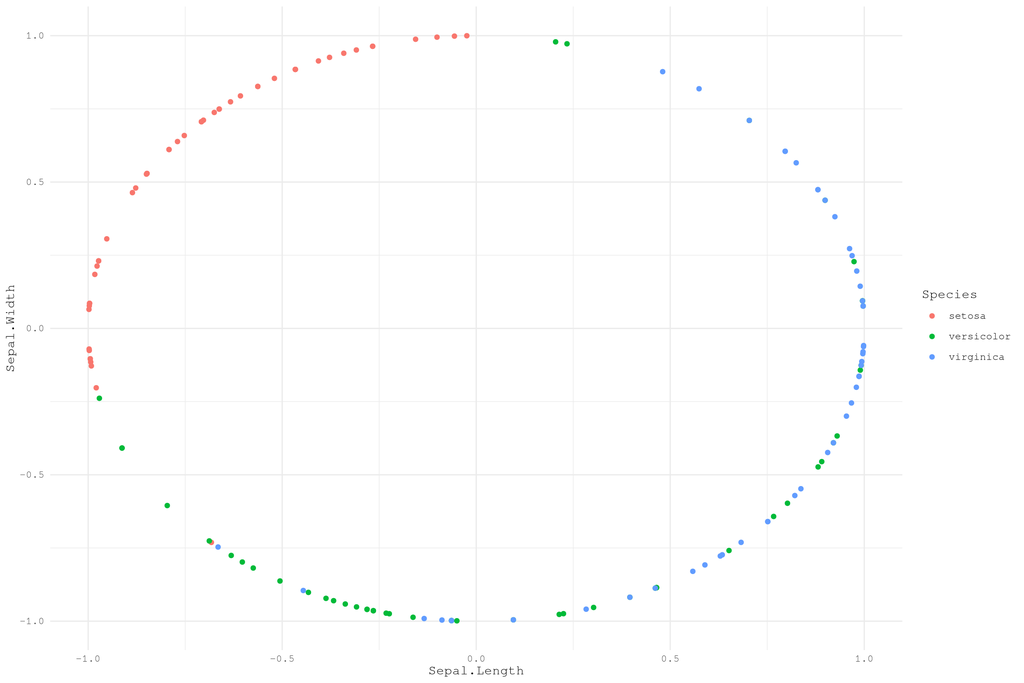

```r
outlier_recipe <- recipe(Species ~ Sepal.Length + Sepal.Width, data = iris) |>
  step_normalize(all_numeric()) |> # Mandatory first step
  step_spatialsign(all_numeric()) |>
  prep()

bake(outlier_recipe, new_data = NULL) |>
  ggplot(aes(Sepal.Length, Sepal.Width, color = Species)) +
  geom_point()+
  theme_minimal()
```

**Pros**:

- Robust to extreme outliers
- Maintains relative angles
- Non-parametric approach

**Cons**:

- Destroys magnitude information
- Requires centered/scaled data
- Not suitable for sparse data

## 2.2 PCA for Data Reduction

**Optimal Workflow**:

1. Resolve skewness (Box-Cox/Yeo-Johnson)
2. Center/scale predictors
3. Determine components via cross-validation/scree plot
4. Validate via resampling

**Component Selection**:

- Retain components before scree plot elbow
- Cumulative variance >80-90%
- Cross-validate performance

**Implementation**:

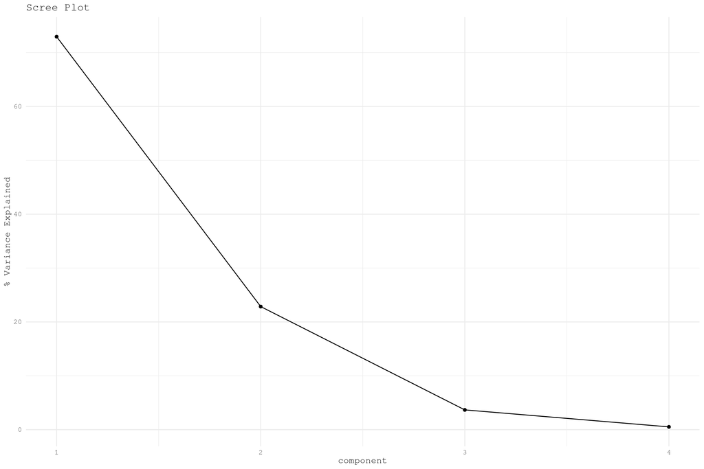

```r
pca_recipe <- recipe(Species ~ ., data = iris) |>
  step_normalize(all_numeric()) |>
  step_pca(all_numeric(), num_comp = 4L) |> #tune()
  prep()

# Scree plot visualization
pca_vars <- tidy(pca_recipe, 2, type = "variance")

pca_vars |>
  filter(terms == "percent variance") |>
  ggplot(aes(component, value)) +
  geom_line() +
  geom_point() +
  labs(title = "Scree Plot", y = "% Variance Explained") +
  theme_minimal()
```

```r
# Component interpretation
tidy(pca_recipe, 2) |>
  filter(component == "PC1") |>
  arrange(-abs(value))
```

```
# A tibble: 4 × 4
  terms         value component id
  <chr>         <dbl> <chr>     <chr>
1 Petal.Length  0.580 PC1       pca_opLvs
2 Petal.Width   0.565 PC1       pca_opLvs
3 Sepal.Length  0.521 PC1       pca_opLvs
4 Sepal.Width  -0.269 PC1       pca_opLvs
```

**Pros**:

- Removes multicollinearity
- Reduces computational load
- Reveals latent structure

**Cons**:

- Loss of interpretability
- Sensitive to scaling
- Linear assumptions
- Supervised methods (PLS) may be preferable for outcome-aware reduction

# 3 Handling Data Challenges

## 3.1 Missing Value Imputation

**Critical Considerations**:

- **Informative missingness**: Is missing pattern related to outcome?
- **Censored data**: Different treatment than MCAR/MAR
- > 5% missing → Consider removal
- Type-appropriate methods (KNN vs regression)

**Imputation Strategies**:

| Scenario | Approach |
| --- | --- |
| <5% missing | Median/mode imputation |
| Continuous predictors | KNN, linear regression, bagging |
| Categorical | Mode, multinomial logit |
| High dimensionality | Regularized models, MICE |

**Implementation**:

```r
ames2 <- ames
ames2$Year_Built2 <- ames2$Year_Built

set.seed(5858)
ames2[sample.int(2930, 1000), c("Year_Built2")] <- NA_integer_
ames2[sample.int(2930, 800), c("Lot_Frontage")] <- NA_integer_

impute_recipe <- recipe(Sale_Price ~ Lot_Frontage + Year_Built2 + Year_Built, data = ames2) |>
  step_impute_knn(Lot_Frontage, neighbors = 3L) |> #tune()
  step_impute_linear(Year_Built2, impute_with = imp_vars(Year_Built)) |>
  prep()

# Assess imputation quality
complete_data <- bake(impute_recipe, new_data = ames2)
cor(complete_data$Year_Built, complete_data$Year_Built2, use = "complete.obs")
```

```
[1] 1
```

```r
cor(complete_data$Lot_Frontage, ames$Lot_Frontage, use = "complete.obs")
```

```
[1] 0.8296254
```

## 3.2 Feature Filtering

**Near-Zero Variance Detection**:

- Frequency ratio > 20
- Unique values < 10%
- Percent unique = n_unique/n * 100

```r
nzv_recipe <- recipe(Species ~ ., data = iris) |>
  step_nzv(all_predictors(), freq_cut = 95/5, unique_cut = 10) |>
  prep()

tidy(nzv_recipe)
```

```
# A tibble: 1 × 6
  number operation type  trained skip  id
   <int> <chr>     <chr> <lgl>   <lgl> <chr>
1      1 step      nzv   TRUE    FALSE nzv_sEXIo
```

**Multicollinearity Handling**:

- Variance Inflation Factor (VIF) > 5-10
- Pairwise correlation threshold
- Iterative removal algorithm

```r
corr_recipe <- recipe(Species ~ ., data = iris) |>
  step_corr(all_numeric(), threshold = 0.9, method = "spearman") |>
  prep()

tidy(corr_recipe)
```

```
# A tibble: 1 × 6
  number operation type  trained skip  id
   <int> <chr>     <chr> <lgl>   <lgl> <chr>
1      1 step      corr  TRUE    FALSE corr_aKa2d
```

# 4 Strategic Feature Engineering

## 4.1 Categorical Encoding & Nonlinear Terms

**Best Practices**:

- Dummy variables for nominal predictors (one-hot encoding)
- Ordered factors for ordinal categories
- Include interaction terms where domain knowledge suggests
- Add polynomial terms for known nonlinear relationships

**Example**:

```r
nonlinear_recipe <- recipe(Species ~ ., data = iris) |>
  step_dummy(all_nominal(), -all_outcomes()) |>
  step_poly(Sepal.Length, degree = 2) |>
  step_interact(~ Sepal.Width:Petal.Length) |>
  prep()
```

## 4.2 Distance to Class Centroids

**When to Use**:

- Classification problems
- Cluster-aware feature engineering
- Improving linear separability
- Augmenting existing feature set

**Implementation**:

```r
centroid_recipe <- recipe(Species ~ ., data = iris) |>
  step_classdist(all_numeric(), class = "Species", pool = FALSE) |>
  prep()

bake(centroid_recipe, new_data = NULL) |>
  select(starts_with("classdist_")) |>
  head()
```

```
# A tibble: 6 × 3
  classdist_setosa classdist_versicolor classdist_virginica
             <dbl>                <dbl>               <dbl>
1           -0.800                 4.74                5.21
2            0.733                 4.42                5.04
3            0.250                 4.55                5.08
4            0.534                 4.42                4.95
5           -0.272                 4.79                5.22
6            1.31                  4.79                5.21
```

## 4.3 Binning Strategies

**When to Avoid**:

- Manual binning pre-analysis
- With tree-based models
- Small sample sizes
- When interpretability trumps accuracy

**Ethical Considerations**:

- Medical diagnostics require maximum accuracy
- Legal implications of arbitrary thresholds
- Potential bias introduction through careless discretization

**Smart Discretization**:

```r
bin_recipe <- recipe(Sale_Price ~ Gr_Liv_Area, data = ames) |>
  step_discretize(Gr_Liv_Area, num_breaks = 4, min_unique = 10) |>
  prep()

bake(bin_recipe, new_data = NULL) |>
  count(Gr_Liv_Area)
```

```
# A tibble: 4 × 2
  Gr_Liv_Area     n
  <fct>       <int>
1 bin1          735
2 bin2          733
3 bin3          729
4 bin4          733
```

# Conclusion

Effective preprocessing requires understanding your data’s story and your model’s needs. As Kuhn emphasizes:

> “Preprocessing decisions should be made with the same care as model selection.”

{tidymodels} provides a cohesive framework to implement these transformations systematically. Remember:

- **Validate** preprocessing via nested resampling
- **Document** transformations for reproducibility
- **Monitor** model applicability domain
- **Consider ethical implications** of engineering choices

By mastering these techniques, you’ll transform raw data into model-ready features while avoiding common pitfalls. The art lies in balancing mathematical rigor with practical implementation - a balance {tidymodels} helps achieve elegantly.